# LAB 1

Applied Survival Analysis

Sarah C. Lotspeich, Ph.D.

Spring 2023

### Preamble

Just a note or two about the way that I code - I’m a big fan of the “pipe” operator to keep my code easy to read. Recently, the `|>` pipe became available in “base R” (i.e., it does not require additional installation). I will use this throughout, and if you’re new to pipes here is a toy example to demonstrate how they are used:

```r
# Take the square root of the sequence 1-10 and then log transform

## Without pipes
log(sqrt(1:10))
```

```
##  [1] 0.0000000 0.3465736 0.5493061 0.6931472 0.8047190 0.8958797 0.9729551
##  [8] 1.0397208 1.0986123 1.1512925
```

```r
## With pipes
1:10 |>
  sqrt() |>
  log()
```

```
##  [1] 0.0000000 0.3465736 0.5493061 0.6931472 0.8047190 0.8958797 0.9729551
##  [8] 1.0397208 1.0986123 1.1512925
```

Mostly I like that the pipes allow me to code in more of a “flow” and to avoid nesting parentheses. I won’t include a Syntax section on future labs; usually, we will start with Installations (if any) and the lab Objectives.

### Installations

To start, we will install the [`survival` package](https://cran.r-project.org/web/packages/survival/index.html), which contains many datasets for us to explore and functions for us to use.

```r
# Install package
install.packages("survival")

# Load package
library(survival)
```

For some data cleaning, we will use the `dplyr` tools.

```r
# Install package
install.packages("dplyr")

# Load package
library(dplyr)
```

For data visualization, we will use the holygrail: `ggplot2`.

```r
# Install package
install.packages("ggplot2")

# Load package
library(ggplot)
```

To summarize patient demographics with ease, we will use `tableone`.

```r
# Install package
install.packages("tableone")

# Load package
library(tableone)
```

We will introduce and install other packages later in the course, as they become relevant to our learning objectives. But for now, `survival` will be all we really need.

### Objectives

For Lab 1, our objectives are the following:

1. Learn how to organize and format survival data in `R`
2. Refresh on built-in functions for common distributions.

### Introduction to the `veteran` data

The `survival` package contains data from Veterans’ Administration Lung Cancer study (i.e., the `veteran` dataset). This was a randomized trial of two treatment regimens for lung cancer, and 137 patients participated. Recruited sometime after diagnosis, patients were followed until death or the end of the study. Additional information such as age and tumor type were also collected.

A brief data dictionary is given in the documentation:

- `trt`: treatment regimen (`1` = standard, `2` = test)
- `celltype`: tumor type (`squamous`, `smallcell`, `adeno`, `large`)
- `time`: time from treatment to either death or censoring (in days)
- `status`: event status (`0` = censored, `1` = dead)
- `karno`: Karnofsky performance score (100=good)
- `diagtime`: time from diagnosis to treatment (in months)
- `age`: in years
- `prior`: prior therapy (`0` = no, `10` = yes)

Recall that in survival analysis, our data need to have three characteristics: (1) a clear time origin, (2) a defined time scale, and (3) an event of interest.

#### *Your turn:* Identify these characteristics in the `veteran` data.

1. Time origin:
2. Time scale:
3. Event of interest:

#### Import the data

Once you’ve loaded the `survival` package, you already have the `veteran` data! Don’t believe me? Try to use it.

```r
veteran |>
  head()
```

```
##   trt celltype time status karno diagtime age prior
## 1   1 squamous   72      1    60        7  69     0
## 2   1 squamous  411      1    70        5  64    10
## 3   1 squamous  228      1    60        3  38     0
## 4   1 squamous  126      1    60        9  63    10
## 5   1 squamous  118      1    70       11  65    10
## 6   1 squamous   10      1    20        5  49     0
```

#### Add labels for `trt` and `prior`

```r
veteran = veteran |>
  mutate(trt = factor(x = trt,
                      levels = c(1, 2),
                      labels = c("standard", "test")),
         prior = factor(x = prior,
                        levels = c(0, 10),
                        labels = c("no", "yes"))
         )

veteran |>
  head()
```

```
##        trt celltype time status karno diagtime age prior
## 1 standard squamous   72      1    60        7  69    no
## 2 standard squamous  411      1    70        5  64   yes
## 3 standard squamous  228      1    60        3  38    no
## 4 standard squamous  126      1    60        9  63   yes
## 5 standard squamous  118      1    70       11  65   yes
## 6 standard squamous   10      1    20        5  49    no
```

Note: `status` is also categorical, but we want to leave it as an integer for some survival-specific functions to come.

### Exploratory data analysis

As with any new dataset, we’re curious! Let’s do some “digging” to get a better idea of who and what are in the `veteran` data.

#### Staggered entry

In our first lecture, we mentioned [**staggered entry**](https://dictionary.apa.org/staggered-entry-design) as one of the common features in survival studies. In the `veteran` dataset, patients weren’t recruited into the study at the exact time of their diagnosis but some time after. Fortunately, this information was captured in the `diagtime` variable.

Create either a graphical or numerical summary of how many patients entered the study when (relative to their diagnoses).

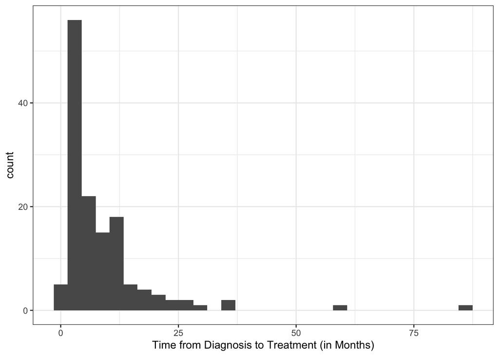

```r
veteran |>
  ggplot(aes(x = diagtime)) +
  geom_histogram() +
  xlab("Time from Diagnosis to Treatment (in Months)") +
  theme_bw()
```

#### Patient demographics

Clinical papers often include a “Table 1,” which describes the demographics of the patients in the study. You can do this manually, but for fun I thought I’d also introduce you to the `tableOne` package, which does this super nicely.

You can create an overall summary of all patients,

```r
# Create table summarizing patients (overall)
CreateTableOne(data = veteran)
```

```
##
##                        Overall
##   n                       137
##   trt = test (%)           68 (49.6)
##   celltype (%)
##      squamous              35 (25.5)
##      smallcell             48 (35.0)
##      adeno                 27 (19.7)
##      large                 27 (19.7)
##   time (mean (SD))     121.63 (157.82)
##   status (mean (SD))     0.93 (0.25)
##   karno (mean (SD))     58.57 (20.04)
##   diagtime (mean (SD))   8.77 (10.61)
##   age (mean (SD))       58.31 (10.54)
##   prior = yes (%)          40 (29.2)
```

or broken down (i.e., stratified) on something like treatment group

```r
# Create table summarizing patients (stratified by trt)
CreateTableOne(strata = "trt",
               data = veteran)
```

[output not shown]

#### Event frequency

```r
with(veteran, table(status))
```

```
## status
##   0   1
##   9 128
```

Of 137 patients in the trial, 128 (93%) died before the study ended, leaving just 9 (7%) censored. We can look at the event frequency further broken down by other risk factors, like…

```r
# Event frequency by treatment group
with(veteran, table(status, trt))
```

```
##       trt
## status standard test
##      0        5    4
##      1       64   64
```

- **By treatment group:** There were 64 deaths among the standard treatment group (0.9275362) and 0.9411765 among the test treatment group.

```r
# Event frequency by prior therapy status
with(veteran, table(status, prior))
```

```
##       prior
## status no yes
##      0  6   3
##      1 91  37
```

- **By prior therapy status:** There were 91 deaths among people without prior therapy (0.9381443) and 0.925 among people with prior therapy.

We could also do this for `celltype`, but there are four levels so interpretations would be a little more cumbersome.

### Preparing for estimation

#### Create time-to-event variable

We got lucky here - the time-to-event variable (`time`) was already calculated for us. Other times we might instead have `date`-type variables and would have to calculate the time-to-event variable from them.

#### Create survival object

Finally we create a special type of R object called a `Surv`, which contains the two types of information needed for survival data: the time-to-event and the event indicator.

```r
# Create Surv object for the veteran data
S = Surv(time = veteran$time,
          event = veteran$status)
S
```

```
##   [1]  72  411  228  126  118   10   82  110  314  100+  42    8  144   25+  11
##  [16]  30  384    4   54   13  123+  97+ 153   59  117   16  151   22   56   21
##  [31]  18  139   20   31   52  287   18   51  122   27   54    7   63  392   10
##  [46]   8   92   35  117  132   12  162    3   95  177  162  216  553  278   12
##  [61] 260  200  156  182+ 143  105  103  250  100  999  112   87+ 231+ 242  991
##  [76] 111    1  587  389   33   25  357  467  201    1   30   44  283   15   25
##  [91] 103+  21   13   87    2   20    7   24   99    8   99   61   25   95   80
## [106]  51   29   24   18   83+  31   51   90   52   73    8   36   48    7  140
## [121] 186   84   19   45   80   52  164   19   53   15   43  340  133  111  231
## [136] 378   49
```

The `Surv` object is a key input to many of the `survival` package functions for estimation and modeling. For example, we could feed `S` into the `survfit()` function to obtain a ``nonparametric’’ (i.e., data-driven, distribution-free) estimate of the survival function.

```r
# Example: Fit a nonparametric survival curve for the veteran data
## You can feed S in from above, in which case you don't need to specify the "data" argument
KM = survfit(formula = S ~ 1)
KM
```

```
## Call: survfit(formula = S ~ 1)
##
##        n events median 0.95LCL 0.95UCL
## [1,] 137    128     80      52     105
```

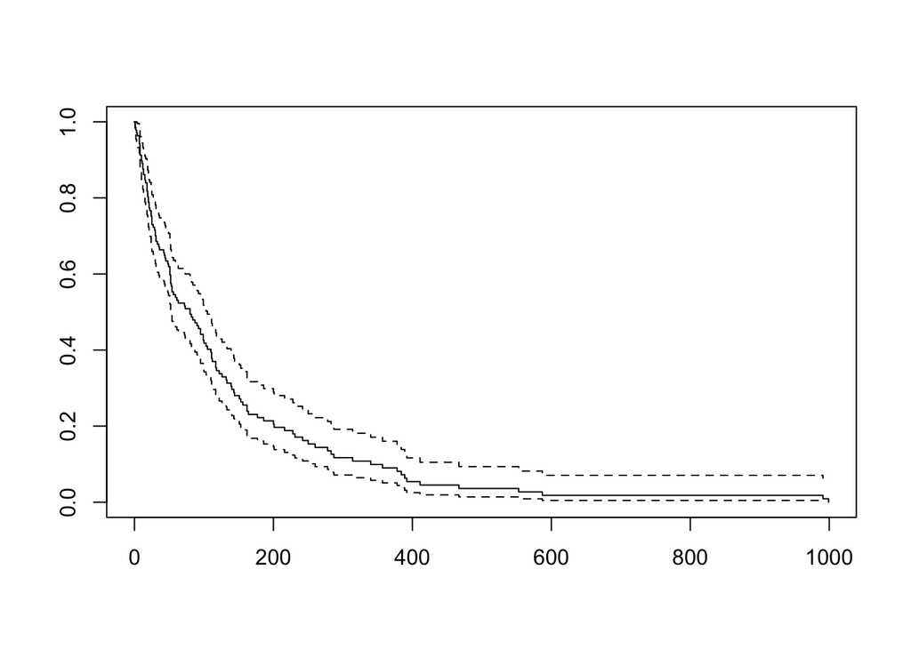

```r
## Or you can define the Surv object inside of the survfit() call
KM = survfit(formula = Surv(time = time, event = status) ~ 1,
             data = veteran)

# Examine estimated survival with plot
plot(KM)
```

### Built-in functions for common distributions

Suppose that, instead of the nonparametric estimate, we have prior knowledge that the `time` to death in the `veteran` data set follows a **log-normal distribution with mean $\mu = 4.2$ and standard deviation $\sigma = 1.4$ (on the log-scale)**. This means that we can use many of the built-in functions for this distribution that come with ``base R.’’

#### Quantity 1: the PDF

```r
# Compute the PDF of time at 14 days
dlnorm(x = 14,
       meanlog = 4.2,
       sdlog = 1.4)
```

```
## [1] 0.01093228
```

Note: If we instead had discrete time data, then the distribution function leading with `d` will be the PMF instead.

#### Quantity 2: the Survival

And `plnorm()` is the CDF $F(x)$. Use it to write your own function for $S(x)$ below, and then compute the survival probability 1 year post-treatment.

```r
# Define a function for the survival
Sx = function(x) {
  # By definition, S(t) = 1 - F(t)
  # 1 - plnorm(q = t,
  #            meanlog = 4.2,
  #            sdlog = 1.4)

  # Or, just set lower.tail = FALSE
  plnorm(q = x,
         meanlog = 4.2,
         sdlog = 1.4,
         lower.tail = FALSE)
}

# Compute survival one year post-treatment
Sx(x = 365)
```

```
## [1] 0.1123333
```

Now, plot the survival function for `time` for 2 years post-treatment. (Hint: You might want to save this plot because we’re going to add layers to it.)

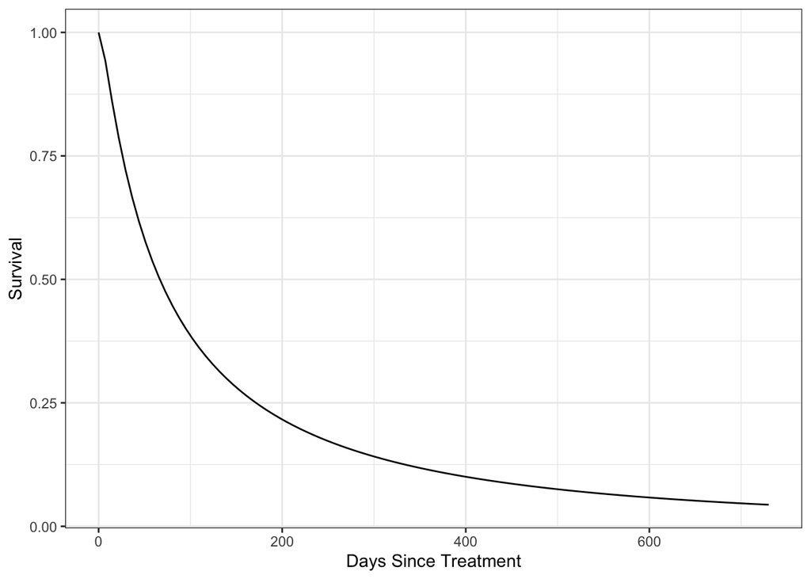

```r
# Plot the survival function for t = 0 to 2 * 365
plot_Sx = ggplot() +
  stat_function(geom = "line",
                fun = Sx,
                xlim = c(0, 365 * 2)) +
  theme_bw() +
  xlab("Days Since Treatment") +
  ylab("Survival")

plot_Sx
```

How long post-treatment is the survival probability 50%? We can find the exact value using the quantile function `qlnorm()`:

```r
Sx50 = qlnorm(p = 0.5,
              meanlog = 4.2,
              sdlog = 1.4)

Sx50
```

```
## [1] 66.68633
```

Annotate this time point on your plot of the survival curve (maybe using dashed lines, shading, etc).

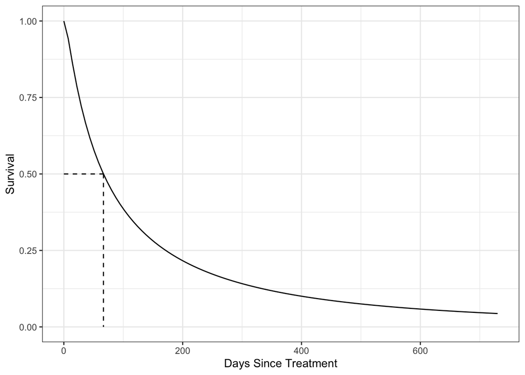

```r
plot_Sx +
  geom_segment(mapping = aes(x = 0,
                             y = 0.5,
                             xend = Sx50,
                             yend = 0.5),
               linetype = 2) +
  geom_segment(mapping = aes(x = Sx50,
                             y = 0.5,
                             xend = Sx50,
                             yend = 0),
               linetype = 2)
```

#### Quantity 3: Hazard function

By definition, we have that for continuous `time` the hazard function is $h(x) = f(x) / S(x)$. We have functions for $f(x)$ and $S(x)$, so let’s put them together to create a function for $h(x)$.

```r
# Define a function for the hazard
hx = function(x) {
  fx = dlnorm(x = x,
              meanlog = 4.2,
              sdlog = 1.4)
  fx / Sx(x = x)
}
```

What is the shape of the hazard function for death in the `veteran` data? You can focus on the first 2 years post treatment. (Hint: You might want to save this plot because we’re going to add layers to it.)

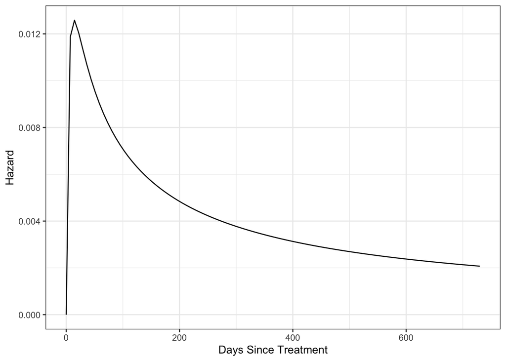

```r
# Plot the hazard function for t = 0 to 2 * 365
plot_hx = ggplot() +
  stat_function(geom = "line",
                fun = hx,
                xlim = c(0, 365 * 2)) +
  theme_bw() +
  xlab("Days Since Treatment") +
  ylab("Hazard")

plot_hx
```

Are there any changepoints in the hazard? Find the times associated with them using built-in numerical optimization functions (e.g., `nlm()` or `optim()`). I’d recommend something small and close to, but not exactly, zero as your start value (e.g., 1 day post-treatment).

```r
# Use nlm() to find x to maximize ht
## (i.e., to minimize -ht)
nlm(f = function(x) -hx(x),
    p = 1)
```

```
## $minimum
## [1] -0.01261474
##
## $estimate
## [1] 12.9326
##
## $gradient
## [1] -2.736904e-09
##
## $code
## [1] 1
##
## $iterations
## [1] 10
```

#### Quantity 4: Cumulative hazard function

Now that we have a nice function for the hazard, we just need to integrate under it to get the cumulative hazard function $H(x)$. (Hint: The `integrate()` function in R would do a really nice job of this.)

```r
# Define a function for the cumulative hazard
Hx = function(x) {
  int = integrate(f = hx,
                  lower = 0,
                  upper = x)
  int$value
}
```

```r
# Calculate cumulative hazard at x = 30
Hx(x = 30)
```

```
## [1] 0.3342769
```

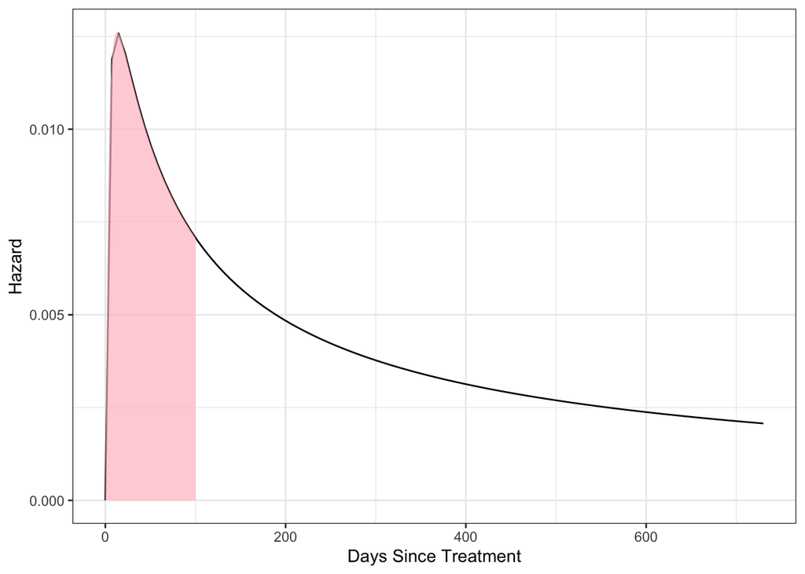

```r
plot_hx +
  stat_function(geom = "area",
                fun = hx,
                xlim = c(0, 100),
                fill = "pink",
                alpha = 0.7
                )
```

#### Quantity 5: Mean residual life

We now have all of the pieces necessary to define a function for the mean residual life function, defined
$$mrl(x)
= \textrm{E}(X - x|X > x) =
\frac{\int_{x}^{\infty}S(t)dt}{S(x)}.$$
Note: the `integrate()` function can handle infinite upper bounds.

```r
# Define function for mean residual life
mrl = function(x) {
  int = integrate(f = Sx,
                  lower = x,
                  upper = Inf)
  int$value / Sx(x = x)
}
```

Calculate the mean residual life after already surviving 10, 50, 100, and 500 days post-treatment.

```r
# Calculate mean residual life at x = 50
mrl(x = 50)
```

```
## [1] 239.0139
```

```r
sapply(X = c(10, 50, 100, 500),
       FUN = mrl)
```

```
## [1] 184.1844 239.0139 298.7853 646.5576
```

#### Quantity 6: Mean life

For log-normal `time`, we know that the mean should be $\exp(4.2 + 1/2 * 1.4 ^ 2) = 177.6826$ days. Let’s use that knowledge to check our functions for mean life!

**Approach 1:** Using the definition of expected value from probability, we can use the PDF to calculate mean life.

```r
integrate(f = function(x) x * dlnorm(x = x, meanlog = 4.2, sdlog = 1.4),
          lower = 0,
          upper = Inf)
```

```
## 177.6828 with absolute error < 0.0048
```

**Approach 2:** Using the definition of expected value from survival, we can use the survival function to calculate mean life.

```r
integrate(f = function(x) Sx(x = x),
          lower = 0,
          upper = Inf)
```

```
## 177.6828 with absolute error < 0.0033
```

**Approach 3:** Use the mean residual life function, since mean life is just mean residual life after already surviving 0 days.

```r
mrl(x = 0)
```

```
## [1] 177.6828
```

#### Quantity 7: Percentiles of life

We have two ways to find the $(100)p$th percentile of a time-to-event variable: (1) by inverting the CDF at $p$ or (2) by inverting the survival at $(1 - p)$.

**Approach 1: Inverting the CDF.** Just like there are built-in functions for the CDF in R, there are functions for the inverse CDFs (i.e., the quantile functions). Try using `qlnorm()` to find the $25$th percentile (i.e., $p = 0.25$) of `time` to death in the `veteran` data set.

```r
# Find median life using qlnorm()
qlnorm(p = 0.25,
       meanlog = 4.2,
       sdlog = 1.4)
```

```
## [1] 25.93814
```

**Approach 2: Inverting the survival.** We can treat the constraint that $S(\phi_{p}) = 1 - p$ as an objective function and use a solver like `uniroot()` to find the value of $\phi_{p}$ to make it true.

```r
# Define the constraint that survival at \phi = 1 - p
constr = function(phi, p) {
  Sx(x = phi) - (1 - p)
}


# Use uniroot() to find phi to satisfy it
uniroot(f = constr,
        interval = c(0, 9999),
        p = 0.25)
```

```
## $root
## [1] 25.93814
##
## $f.root
## [1] 4.827805e-12
##
## $iter
## [1] 10
##
## $init.it
## [1] NA
##
## $estim.prec
## [1] 6.103516e-05
```